# Wittenberg University - Master of Science in Analytics

ANLT 510 - Advanced Statistics and Modeling

Day 1: Supervised Modeling Process

14 Oct 2021

# Introduction

- In this presentation you’ll get introduced to several useful concepts for building machine learning models
- These concepts are applicable regardless of the type of machine learning model you’re building
  - Contrasting the modeling process and the model itself
  - Data splitting
  - Several nuances in the R modeling ecosystem
  - Resampling Methods
  - The bias-variance trade-off
  - Model evaluation metrics

## Overview

- The process of building machine learning models is **highly** iterative - where you may need to revisit any of these steps multiple times
- In the course of building a ML model it’s not unusual to apply, evaluate, and modify these steps before a final, optimal model is determined
- It important to have a documented and defensible process to have confidence in your model results

- Note: Many of the model building process(es) demonstrated in the textbook are **idealized**
  - You’ll be directed on what steps to carry out
  - The data sets have already been cleaned
  - The objective of the analysis has been made clear
- In real data science projects, you’ll work with clients that have
  1. A vague idea of what they really want out of the project
  2. An unrealistic belief in the quality (and quantity) of their data

## Prerequisites

- To follow along with the rest of this presentation, you’ll need to install and load a few R Packages

```r
## install packages into local library
install.packages(c(rsample,
                   modeldata,
                   caret,
                   tidyverse,
                   cowplot,
                   h2o,
                   DT))
```

```r
## load packages from your library into the current R session
library(rsample)
library(modeldata)
library(caret)
library(tidyverse)
library(cowplot)
library(h2o)
library(DT)
```

- Likewise, you’ll want to load the `ames` and `attrition` data sets from the `modeldata` package

```r
data(ames, package = 'modeldata')
# To learn more about this data set run:
### help(ames, package = "modeldata")
# To view a snapshot of this data set run:
### DT::datatable(head(ames, n = 20))

data(attrition, package = 'modeldata')
# To learn more about this data set
### help(attrition, package = "modeldata")
# To view a snapshot of this data set run:
### DT::datatable(head(attrition, n = 20))
```

- Now that we have the environment set up and data sets loaded - Let’s get started

# Data Splitting

## Generalizability

- The goal of this model building process is to create a model that is **Generalizable**
  - Accurately learns the relationship between the features and the target variable in our current data
  - Can accurately predict the target variable in data that have not yet been collected
- A model that isn’t generalizable is said to be overfitting the training data
  - This means that our model can almost perfectly describe the relationship between the inputs and outputs in the data on which it was trained
  - However, this model does a poor job of describing the relationships when it is tasked with evaluating new data
- We check for generalizability by simulating this process on our data set
- Split our data into two smaller data sets
  - **Training Set**: these data are used to develop feature sets, train our algorithms, tune hyper-parameters, compare across models, and all of the other activities to reach a final model
  - **Test Set**: having chosen a final model, these data are used to estimate an unbiased assessment of the model’s performance (generalization error).
- We spend a lot of time on our training set but won’t touch the test set until the end

[figure not shown]

## What’s the right split?

- In the literature you’ll see the following train-test split recommendations
  - 60% (training) - 40% (testing)
  - 70%-30%
  - 80%-20%
- For smaller data sets ($n<500$):
  - Allocating too many observations to training won’t allow a good assessment of predictive performance. We may find a model that fits the training data very well, but is not generalizable (overfitting)
  - Allocating too many observations to testing won’t allow us to get a good assessment of model parameters
- As the number of observations in the data set gets larger ($n>100K$)
  - The choice of split has a lesser effect on the model outputs
  - However, a smaller training sample may significantly reduce the computation speed when building the model
- As the number of model parameters $p$ increases ($p \geq n$)
  - Larger sample sizes are often required to identify consistent signals in the features

## Mechanics of data splitting

- Two most common ways of splitting data include:
  - Simple random sampling: randomly select observations
  - Stratified sampling: preserving distributions -classification: sampling within the classes to preserve the distribution of the outcome in the training and test sets  
    -regression: determine the quartiles of the data set and sample within those artificial groups

```r
set.seed(123) # for reproducibility
split <- rsample::initial_split(diamonds,
                                strata = "price",
                                prop = 0.7)

train <- rsample::training(split)
test  <- rsample::testing(split)

# Do the distributions line up?
ggplot(train, aes(x = price)) +
  geom_line(stat = "density",
            trim = TRUE) +
  geom_line(data = test,
            stat = "density",
            trim = TRUE, col = "red")
```

[output not shown]

## Your Turn!

1. Use **rsample** to split the Ames housing data (`ames`) and the Employee attrition data (`attrition`) using stratified sampling and with a 70% split.

```r
# ames data
set.seed(123)
ames_split <- rsample::initial_split(ames, prop = _____, strata = "Sale_Price")
ames_train <- rsample::training(_____)
ames_test  <- rsample::testing(_____)

# attrition data
set.seed(123)
churn_split <- rsample::initial_split(attrition, prop = _____, strata = "Attrition")
churn_train <- rsample::training(_____)
churn_test  <- rsample::testing(_____)
```

2. Verify that the distribution between training and test sets are similar.

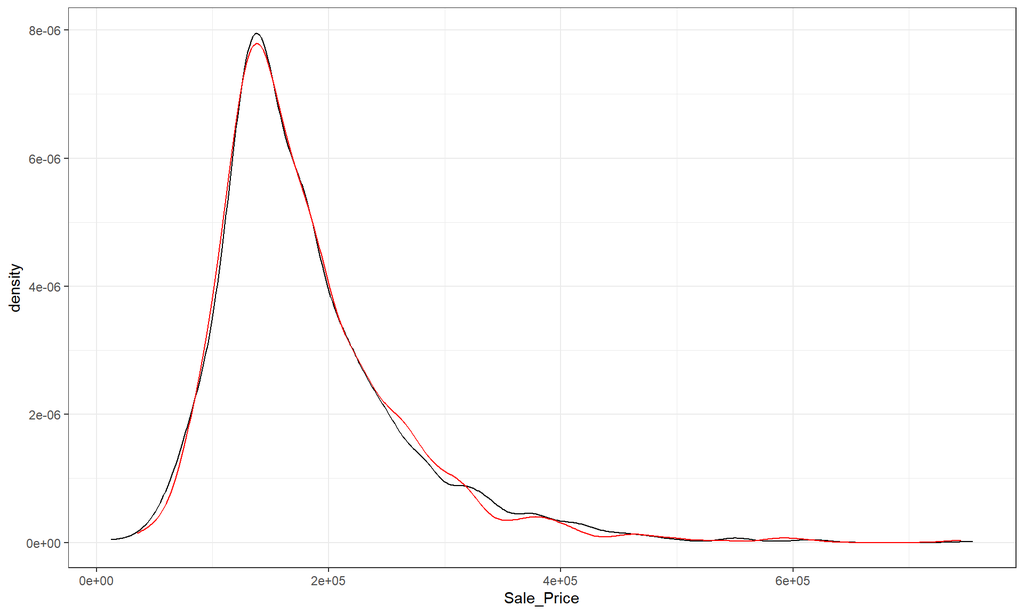

```r
## Ames Housing Data
set.seed(123)
ames_split <- rsample::initial_split(ames,
                                     prop = 0.7,
                                     strata = "Sale_Price")

ames_train <- rsample::training(ames_split)
ames_test  <- rsample::testing(ames_split)

# Do the distributions line up?
ggplot(ames_train, aes(x = Sale_Price)) +
  geom_line(stat = "density",
            trim = TRUE) +
  geom_line(data = ames_test,
            stat = "density",
            trim = TRUE, col = "red")
```

```r
## Employee Attrition Data
set.seed(123)
churn_split <- rsample::initial_split(attrition,
                                      prop = 0.7,
                                      strata = "Attrition")

churn_train <- rsample::training(churn_split)
churn_test  <- rsample::testing(churn_split)

# consistent response ratio between train & test
table(churn_train$Attrition) %>% prop.table()
```

```
       No       Yes
0.8394942 0.1605058
```

```r
table(churn_test$Attrition)  %>% prop.table()
```

```
       No       Yes
0.8371041 0.1628959
```

# Creating models in R

## Many interfaces

- To fit a model to our data, the model terms must be specified
- There are **three main interfaces** for doing this:
  1. Formula interface
  2. XY interface
  3. Variable name specification

```r
### 1. FORMULA INTERFACE
# Variables + interactions
model_fn(Sale_Price ~ Neighborhood + Year_Sold + Neighborhood:Year_Sold,
         data = ames_train)

# Shorthand for all predictors
model_fn(Sale_Price ~ .,
         data = ames_train)

# Inline functions / transformations
model_fn(log10(Sale_Price) ~ ns(Longitude, df = 3) + ns(Latitude, df = 3),
         data = ames_train)
```

```r
### 2. X-Y INTERFACE

# Usually, the variables must all be numeric
features <- c("Year_Sold", "Longitude", "Latitude")
model_fn(x = ames_train[, features], y = ames_train$Sale_Price)
```

```r
### 3. VARIABLE NAME SPECIFICATION

# specify x & y by character strings
model_fn(x = c("Year_Sold", "Longitude", "Latitude"),
         y = "Sale_Price",
         data = ames.h2o)
```

- We can get around these inconsistencies with meta-engines

## Meta engines

- The prevalence of ML packages has provided an abundance of direct and meta engines that can be used
- For example, each of the following produce the same linear regression model output

```r
lm_lm    <- stats::lm(Sale_Price ~ .,
                      data = ames_train)

lm_glm   <- stats::glm(Sale_Price ~ .,
                       data = ames_train,
                       family = gaussian)

lm_caret <- caret::train(Sale_Price ~ .,
                         data = ames_train,
                         method = "lm")
```

- `lm()` and `glm()` are two different direct engines that can be used to fit the linear model directly
- `caret::train()` is a meta engine (aggregator) that allows you to apply almost any direct engine with `method = ?`
- Using direct engines provides more flexibility but requires you to be familiar with the syntax nuances

Revised from Max Kuhn’s 2019 RStudio Conference talk(https://resources.rstudio.com/rstudio-conf-2019/parsnip-a-tidy-model-interface)

| Algorithm | Package | Code |
| --- | --- | --- |
| Linear discriminant analysis | MASS | `predict(obj)` |
| Generalized linear model | stats | `predict(obj, type = "response")` |
| Mixture discriminant analysis | mda | `predict(obj, type = "posterior")` |
| Decision tree | rpart | `predict(obj, type = "prob")` |
| Random Forest | ranger | `predict(obj)$predictions` |
| Gradient boosting machine | gbm | `predict(obj, type = "response", n.trees)` |

# Resampling Methods

## Overview

- *Resampling* provides an approach for us to repeatedly fit a model of interest to parts of the training data and testing the performance on other parts
- Allows us to *estimate* the generalization error while training, tuning, and comparing models without using the test data set
- The two most commonly used resampling methods include
  - *k*-fold cross validation
  - bootstrapping

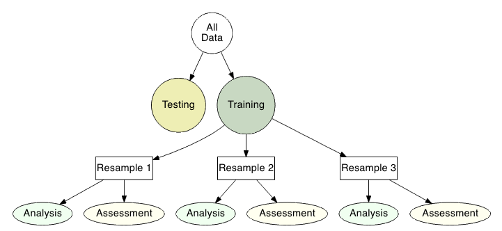

Image by Max Kuhn (https://bookdown.org/max/FES/review-predictive-modeling-process.html#fig:review-resamp-scheme)

## *K*-fold cross valiation

- Randomly divides the training data into $k$ groups of approximately equal size
- Assign one block as the test block and the other $k-1$ blocks as training blocks
- Train the model on each of the folds (aka training blocks) and evaluate its performance on test block
- Average the model’s performance across all folds
- $k$ is often taken to be 5 or 10

- Pro tip: for smaller data sets ($n < 10,000$), repeating a 10-fold cross validation 5 or 10 times will improve accuracy of your estimated performance
- cross-validation is performed to give you a better sense of how your model performs - it WILL NOT improve the performance of your model
- In the code chunk below we implement 10-fold cross validation on the `mtcars` data set ($n = 32$)

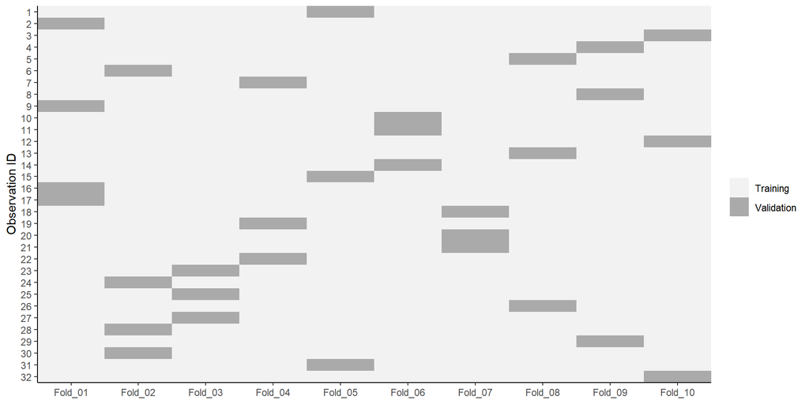

```r
### Create 10 cross-validation splits
### for the mtcars data set
cv <- rsample::vfold_cv(mtcars, 10)

### For each split
cv_plot <- cv$splits %>%
  purrr::map2_dfr(seq_along(cv$splits), ~ mtcars %>% mutate(
    Resample = paste0("Fold_", stringr::str_pad(.y, 2, pad = 0)),
    ID = row_number(),
    Data = ifelse(ID %in% .x$in_id, "Training", "Validation"))) %>%
  ggplot(aes(Resample, ID, fill = Data)) +
  geom_tile() +
  scale_fill_manual(values = c("#f2f2f2", "#AAAAAA")) +
  scale_y_reverse("Observation ID",
                  breaks = 1:nrow(mtcars),
                  expand = c(0, 0)) +
  scale_x_discrete(NULL, expand = c(0, 0)) +
  theme_classic() +
  theme(legend.title=element_blank())

cv_plot
```

## Applying $k$-fold cross valiation

- There are three main approaches to implement cross-validation
  - Via a direct modeling engine
  - via a meta modeling engine
  - Indepently, outside of a model engine

```r
# example of 10 fold CV in h2o direct engine
h2o_cv <- h2o::h2o.glm(
  x = -1,
  y = 1,
  training_frame = h2o::as.h2o(mtcars),
  nfolds = 10 #<<
  )
```

```r
# example of 10 fold CV in caret
caret_cv <- caret::train(
  Sale_Price ~ .,
  data = ames_train,
  method = "lm",
  trControl = caret::trainControl(method = "cv",  number = 10) #<<
  )
```

```r
# example of 10 fold CV with rsample::vfold_cv
ext_cv <- rsample::vfold_cv(ames_train, v = 10)
ext_cv
```

```
#  10-fold cross-validation
# A tibble: 10 x 2
   splits             id
   <list>             <chr>
 1 <split [1844/205]> Fold01
 2 <split [1844/205]> Fold02
 3 <split [1844/205]> Fold03
 4 <split [1844/205]> Fold04
 5 <split [1844/205]> Fold05
 6 <split [1844/205]> Fold06
 7 <split [1844/205]> Fold07
 8 <split [1844/205]> Fold08
 9 <split [1844/205]> Fold09
10 <split [1845/204]> Fold10
```

```r
names(ext_cv$splits$`1`)
```

## Bootstrapping

- A bootstrap sample is the same size as the training set but each data point is selected *with replacement*
  - **Analysis set** Will contain more than one replicate of a training set instance
  - **Assessment set** Contains all samples that were never included in the corresponding bootstrap set. Often called the *“out-of-bag”* sample and can vary in size!

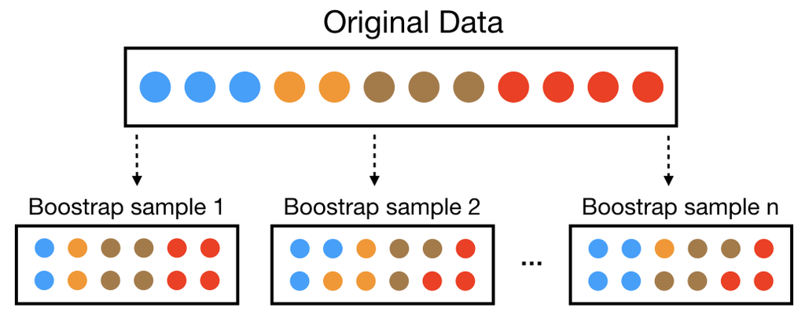

- On average, 63.21% of the training set is contained at least once in the bootstrap sample
- Pro tip For smaller data sets (*n < 500*), bootstrapping can have biased error estimates; use repeated k-fold or corrected bootstrapping methods.

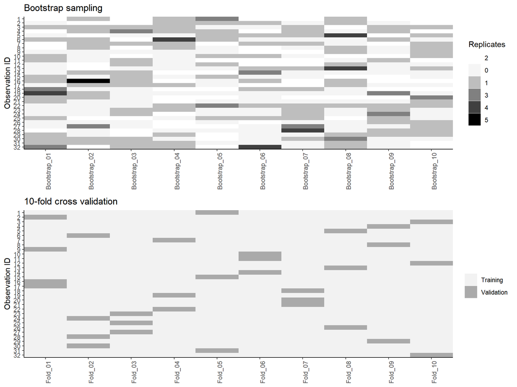

```r
### Create 10 sets of bootstrap samples
boots <- rsample::bootstraps(mtcars, 10)

boots_plot <- boots$splits %>%
  purrr:::map2_dfr(seq_along(boots$splits), ~ mtcars %>%
             mutate(
               Resample = paste0("Bootstrap_", stringr::str_pad(.y, 2, pad = 0)),
               ID = row_number()
             ) %>%
             group_by(ID) %>%
             mutate(Replicates = factor(sum(ID == .x$in_id)))) %>%
  ggplot(aes(Resample, ID, fill = Replicates)) +
  geom_tile() +
  scale_fill_manual(values = c("#FFFFFF", "#F5F5F5", "#BEBEBE", "#808080", "#404040", "#000000")) +
  scale_y_reverse("Observation ID",
                  breaks = 1:nrow(mtcars),
                  expand = c(0, 0)) +
  scale_x_discrete(NULL, expand = c(0, 0)) +
  theme_classic() +
  theme(axis.text.x = element_text(angle = 90, hjust = 1)) +
  ggtitle("Bootstrap sampling")

cv_plot <- cv_plot +
  ggtitle("10-fold cross validation") +
  theme(axis.text.x = element_text(angle = 90, hjust = 1))

cowplot::plot_grid(boots_plot, cv_plot, align = "v", nrow = 2)
```

## Applying

- Similar to cross validation, we can incorporate bootstrapping with:
  - meta engines
  - external to engines
- However, bootstrapping is more of an internal resampling procedure that is naturally built into certain ML algorithms:
  - Bagging
  - Random forests
  - GBMs

```r
# Within a meta engine:
# example of 10 bootstrap samples in caret
caret_boot <- caret::train(
  Sale_Price ~ .,
  data = ames_train,
  method = "lm",
  trControl = caret::trainControl(method = "boot",  number = 10) #<<
  )
```

```r
# External to engine
# example of 10 bootstrapped samples with rsample::bootstraps
rsample::bootstraps(ames, times = 10)
```

```
# Bootstrap sampling
# A tibble: 10 x 2
   splits              id
   <list>              <chr>
 1 <split [2930/1051]> Bootstrap01
 2 <split [2930/1075]> Bootstrap02
 3 <split [2930/1069]> Bootstrap03
 4 <split [2930/1049]> Bootstrap04
 5 <split [2930/1064]> Bootstrap05
 6 <split [2930/1072]> Bootstrap06
 7 <split [2930/1074]> Bootstrap07
 8 <split [2930/1077]> Bootstrap08
 9 <split [2930/1077]> Bootstrap09
10 <split [2930/1057]> Bootstrap10
```

# Bias-Variance Trade-off

## Overview

- Prediction errors can be decomposed into two main sub-components we have control over:
  - Errors due to “bias”
  - Errors due to “variance”
- There is a trade-off between a model’s ability to minimize bias and variance.
- Understanding how different sources of error lead to bias and variance helps us improve the data fitting process resulting in more accurate models.

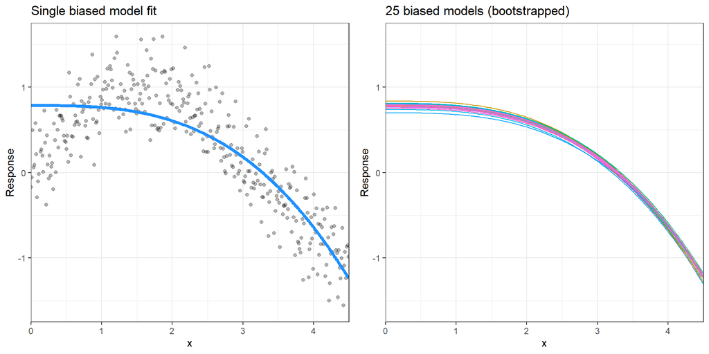

```r
# Simulate some nonlinear monotonic data
set.seed(123)  # for reproducibility
x <- seq(from = 0, to = 2 * pi, length = 500)
y <- sin(x) + rnorm(length(x), sd = 0.3)

df <- data.frame(x, y) %>% filter(x < 4.5)

# single model fit
bias_model <- lm(y ~ I(x^3), data = df)
df$predictions <- predict(bias_model, df)

p1 <- ggplot(df, aes(x, y)) +
  geom_point(alpha = .3) +
  geom_line(aes(x, predictions), size = 1.5, color = "dodgerblue") +
  scale_y_continuous("Response", limits = c(-1.75, 1.75), expand = c(0, 0)) +
  scale_x_continuous(limits = c(0, 4.5), expand = c(0, 0)) +
  ggtitle("Single biased model fit")

# bootstrapped model fit
bootstrap_n <- 25
bootstrap_results <- NULL
for(i in seq_len(bootstrap_n)) {
  # reproducible sampled data frames
  set.seed(i)
  index <- sample(seq_len(nrow(df)), nrow(df), replace = TRUE)
  df_sim <- df[index, ]

  # fit model and add predictions to results data frame
  fit <- lm(y ~ I(x^3), data = df_sim)
  df_sim$predictions <- predict(fit, df_sim)
  df_sim$model <- paste0("model", i)
  df_sim$ob <- index
  bootstrap_results <- rbind(bootstrap_results, df_sim)
}

p2 <- ggplot(bootstrap_results, aes(x, predictions, color = model)) +
  geom_line(show.legend = FALSE, size = .5) +
  scale_y_continuous("Response", limits = c(-1.75, 1.75), expand = c(0, 0)) +
  scale_x_continuous(limits = c(0, 4.5), expand = c(0, 0)) +
  ggtitle("25 biased models (bootstrapped)")

gridExtra::grid.arrange(p1, p2, nrow = 1)
```

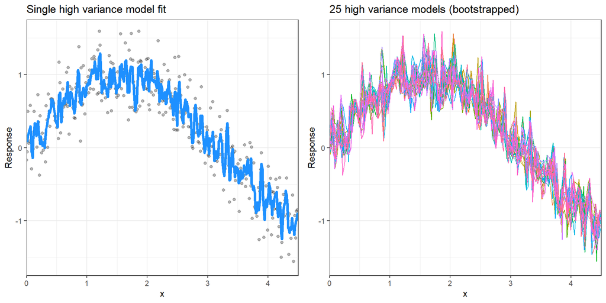

```r
# Simulate some nonlinear monotonic data
set.seed(123)  # for reproducibility
x <- seq(from = 0, to = 2 * pi, length = 500)
y <- sin(x) + rnorm(length(x), sd = 0.3)

df <- data.frame(x, y) %>% filter(x < 4.5)

# single model fit
variance_model <- caret::knnreg(y ~ x, k = 3, data = df)
df$predictions <- predict(variance_model, df)

p1 <- ggplot(df, aes(x, y)) +
  geom_point(alpha = .3) +
  geom_line(aes(x, predictions), size = 1.5, color = "dodgerblue") +
  scale_y_continuous("Response", limits = c(-1.75, 1.75), expand = c(0, 0)) +
  scale_x_continuous(limits = c(0, 4.5), expand = c(0, 0)) +
  ggtitle("Single high variance model fit")

# bootstrapped model fit
bootstrap_n <- 25
bootstrap_results <- NULL
for(i in seq_len(bootstrap_n)) {
  # reproducible sampled data frames
  set.seed(i)
  index <- sample(seq_len(nrow(df)), nrow(df), replace = TRUE)
  df_sim <- df[index, ]

  # fit model and add predictions to results data frame
  fit <- caret::knnreg(y ~ x, k = 3, data = df_sim)
  df_sim$predictions <- predict(fit, df_sim)
  df_sim$model <- paste0("model", i)
  df_sim$ob <- index
  bootstrap_results <- rbind(bootstrap_results, df_sim)
}

p2 <- ggplot(bootstrap_results, aes(x, predictions, color = model)) +
  geom_line(show.legend = FALSE) +
  scale_y_continuous("Response", limits = c(-1.75, 1.75), expand = c(0, 0)) +
  scale_x_continuous(limits = c(0, 4.5), expand = c(0, 0)) +
  ggtitle("25 high variance models (bootstrapped)")

gridExtra::grid.arrange(p1, p2, nrow = 1)
```

- Some models naturally have higher bias - while others have higher variance
  - high bias - generalized linear models
  - high variance - tree-based models, NNets, KNN
- Hyperparameters can help to control bias-variance trade-off

## Hyperparameter tuning

- Hyperparameters (aka *tuning parameters*) can be thought of as “knobs” to control of complexity of machine learning algorithms and, therefore, the bias-variance trade-off

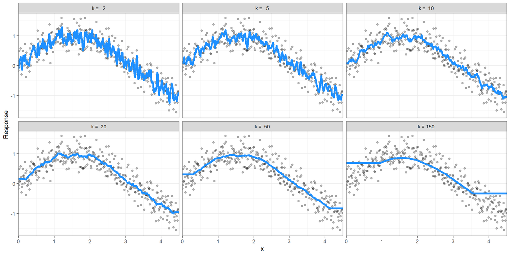

- $k$-nearest neighbor model with differing values for $k$
  - Small $k$ value has too much variance
  - Big $k$ value has too much bias
  - How do we find the optimal value?

## Grid search

- A grid search is an automated approach to searching across many combinations of hyperparameter values

```r
# resampling procedure
cv <- caret::trainControl(method = "repeatedcv",
                          number = 10,
                          repeats = 10)

# define grid search
hyper_grid <- expand.grid(k = seq(2, 150, by = 2))

# perform grid search with caret
knn_fit <- caret::train(
  x ~ y,
  data = df,
  method = "knn",
  trControl = cv,
  tuneGrid = hyper_grid
  )
```

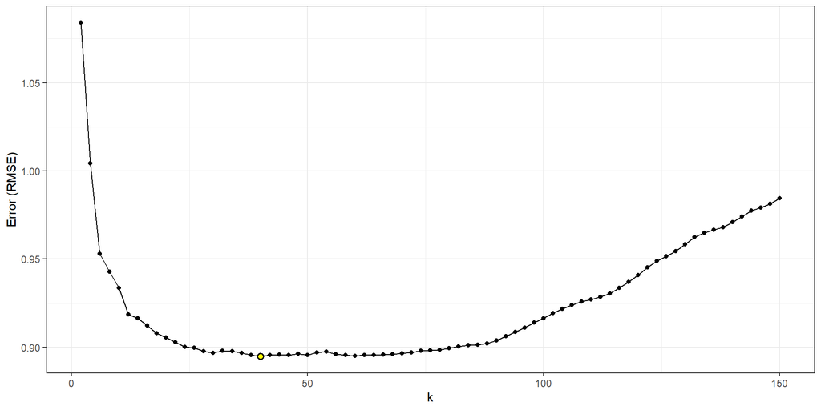

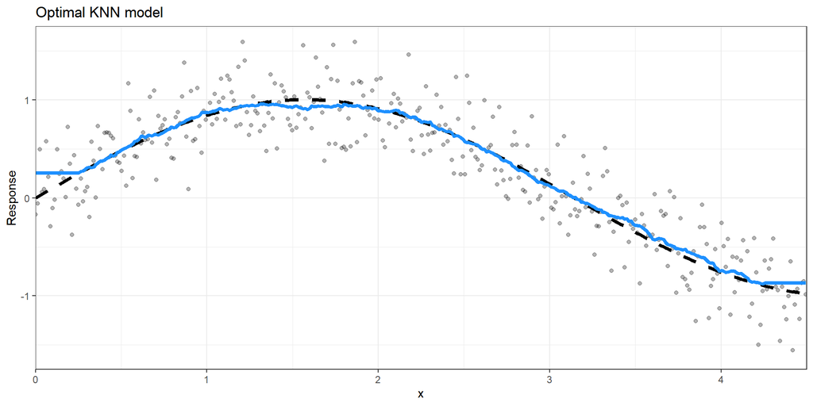

# Model Evaluation Metrics

## Overview

- Regression
  - Mean Square Error (MSE)
  - Root Mean Square Error (RMSE)
  - Mean Absolute Error (MAE)
  - Mean Absolute Percent Error (MAPE)
  - Root Mean Squared Logarithmic Error (RMSLE)
- Classification
  - Classification Accuracy
  - Recall vs. Specificity
  - $F_1$ Score
  - Log Loss

## Model evaluation

- Regression
  - Mean Square Error (MSE)
  - Root Mean Square Error (RMSE)
  - Mean Absolute Error (MAE)
  - Mean Absolute Percent Error (MAPE)
  - Root Mean Squared Logarithmic Error (RMSLE)

$$MSE = \frac{1}{n}\sum^n_{i=1}(y_i - \hat y_i)^2$$

- Classification
  - Classification Accuracy
  - Recall vs. Specificity
  - $F_1$ Score
  - Log Loss

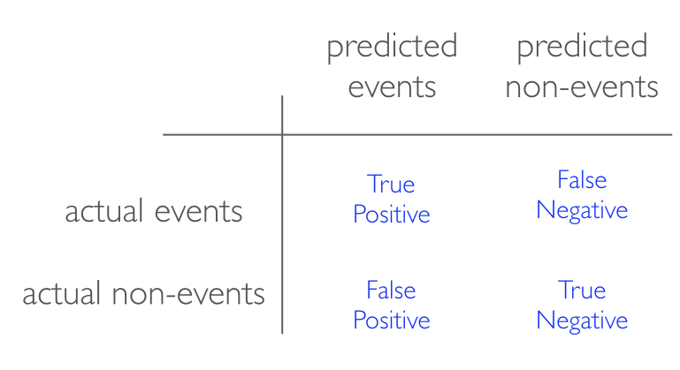

# Putting the process together

## Overview

- Let’s put these pieces together and analyze the Ames housing data:
  - 1. Split into training vs testing data
  - 2. Specify a resampling procedure
  - 3. Create our hyperparameter grid
  - 4. Execute grid search
  - 5. Evaluate performance
- This grid search takes ~2 min

```r
# 1. stratified sampling with the rsample package
set.seed(123)
split  <- rsample::initial_split(ames,
                                 prop = 0.7,
                                 strata = "Sale_Price")

ames_train  <- rsample::training(split)
ames_test   <- rsample::testing(split)

# 2. create a resampling method
cv <- caret::trainControl(
  method = "repeatedcv",
  number = 10,
  repeats = 5
  )

# 3. create a hyperparameter grid search
hyper_grid <- expand.grid(k = seq(2, 26, by = 2))

# 4. execute grid search with knn model
#    use RMSE as preferred metric
knn_fit <- caret::train(
  Sale_Price ~ .,
  data = ames_train,
  method = "knn",
  trControl = cv,
  tuneGrid = hyper_grid,
  metric = "RMSE"
  )

# 5. evaluate results
# print model results
knn_fit
```

```
k-Nearest Neighbors

2049 samples
  73 predictor

No pre-processing
Resampling: Cross-Validated (10 fold, repeated 5 times)
Summary of sample sizes: 1844, 1844, 1843, 1844, 1844, 1845, ...
Resampling results across tuning parameters:

  k   RMSE      Rsquared   MAE
   2  47307.41  0.6582825  31141.17
   4  44781.08  0.6899670  29291.15
   6  43845.76  0.7045112  28905.85
   8  44241.74  0.7025067  29087.97
  10  44323.66  0.7055874  29121.28
  12  44486.01  0.7076171  29149.28
  14  44789.95  0.7078507  29297.56
  16  45111.55  0.7076296  29474.30
  18  45359.70  0.7074634  29643.31
  20  45736.63  0.7055328  29898.39
  22  46161.37  0.7023731  30166.85
  24  46569.97  0.6993002  30456.33
  26  47016.94  0.6958784  30736.64

RMSE was used to select the optimal model using the smallest value.
The final value used for the model was k = 6.
```

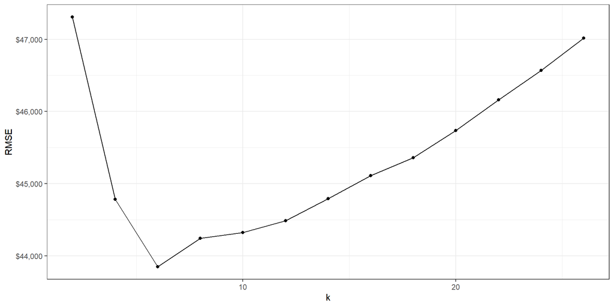

```r
# plot cross validation results
ggplot(knn_fit$results, aes(k, RMSE)) +
  geom_line() +
  geom_point() +
  scale_y_continuous(labels = scales::dollar)
```

## Is this the best predictive model we can find?

- We may have identified the optimal $k$-nearest neighbor model for our given data set but this doesn’t mean we’ve found the best possible overall model
- Moreover, we have not considered potential feature and target engineering options

# Questions?

[figure not shown]